# Machine Learning - Prediction Assignment

Chris Chubb

December 12, 2016

## Problem Definition

One thing that people regularly do is quantify how much of a particular activity they do, but they rarely quantify how well they do it. In this project, your goal will be to use data from accelerometers on the belt, forearm, arm, and dumbell of 6 participants.

### Background

Using devices such as Jawbone Up, Nike FuelBand, and Fitbit it is now possible to collect a large amount of data about personal activity relatively inexpensively. These type of devices are part of the quantified self movement - a group of enthusiasts who take measurements about themselves regularly to improve their health, to find patterns in their behavior, or because they are tech geeks. One thing that people regularly do is quantify how much of a particular activity they do, but they rarely quantify how well they do it. In this project, your goal will be to use data from accelerometers on the belt, forearm, arm, and dumbell of 6 participants. They were asked to perform barbell lifts correctly and incorrectly in 5 different ways. More information is available from the website here: http://groupware.les.inf.puc-rio.br/har (see the section on the Weight Lifting Exercise Dataset).

### Data Loading

```r
if (! file.exists("data/pml-training.csv")) {
  download.file("https://d396qusza40orc.cloudfront.net/predmachlearn/pml-training.csv", "data/pml-training.csv")
  download.file("https://d396qusza40orc.cloudfront.net/predmachlearn/pml-testing.csv", "data/pml-testing.csv")
}

training_all = read.csv("data/pml-training.csv", stringsAsFactors=FALSE, strip.white = TRUE, na.strings = c("", "NA", "#DIV/0!"))
training_all$classe = as.factor(training_all$classe)
testing_all = read.csv("data/pml-testing.csv", stringsAsFactors=FALSE, strip.white = TRUE, na.strings = c("", "NA", "#DIV/0!"))
```

## Exploratory Analysis and Data Shaping

After examining the data, it was noticed that there were a number of fields that were predominately NA. Because NA values are not usable to most modeling algorithms, the NA fields were removed. In addition, variables that were row identifiers, timestamps and user identifiers were also removed.

```r
NAs <- unlist(lapply(training_all, function(x) sum(is.na(x))/length(x))) #What percentage of each column is NA
NAs[1:7] <- 1; #Throw out X and the user and time series fields as well.

#Split training data into training and validation
set.seed(8675309)
inTrain = createDataPartition(training_all$classe, p = 0.7, list=FALSE)

training <- training_all[inTrain,names(which(NAs == 0))] #Throw out those predictors
validation <- training_all[-inTrain,names(which(NAs == 0))]
testing <- testing_all[,names(testing_all) %in% names(which(NAs == 0))]
```

After the un-useful variables have been removed, the next step is to check for other variables that may be highly correlated so that they may be removed in order to reduce bias.

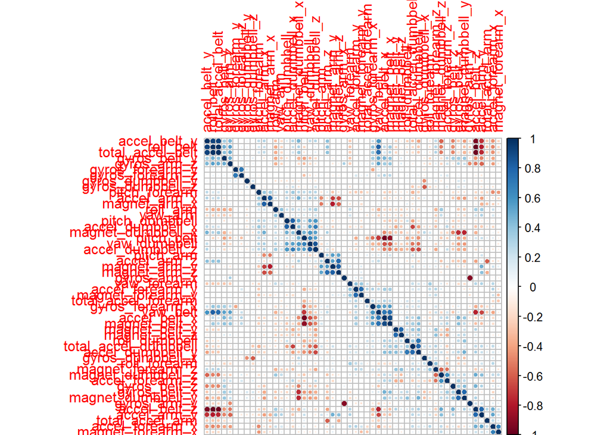

```r
correlation_matrix <- cor(training[, names(training) != "classe"])
corrplot(correlation_matrix, order = "hclust")
```

There are 8 columns with a correlation at least 95%.

```r
rownames(cor_fields<-which((correlation_matrix < -0.95 | correlation_matrix > 0.95) & correlation_matrix != 1, arr.ind=TRUE))
```

```
## [1] "total_accel_belt" "accel_belt_z"     "accel_belt_x"
## [4] "roll_belt"        "accel_belt_z"     "pitch_belt"
## [7] "roll_belt"        "total_accel_belt"
```

Three of them are correlated with the others, so removing them will help reduce bias.

```r
training <- training[, !(names(training) %in% c("total_accel_belt", "accel_belt_z", "roll_belt"))]
validation <- validation[, !(names(validation) %in% c("total_accel_belt", "accel_belt_z", "roll_belt"))]
testing <- testing[, !(names(testing) %in% c("total_accel_belt", "accel_belt_z", "roll_belt"))]
cols <- dim(training)[2] - 1
```

We are now left with 49 variables in the training set.

## First Model: Random Forests

Random forests are an excellent method for building a classification model. As options we will be doing Principle Component Analysis as a first step to suppress unimportant variables, as well as using Cross Validation instead of bootstrapping as it is much faster. Because we are doing PCA, we need to apply the same PCA model to all data sets.

```r
set.seed(8675309)

PCA <- preProcess(training[,names(training) != "classe"], method="pca")
training_PCA <- predict(PCA, training[,names(training) != "classe"])
validation_PCA <- predict(PCA, validation[,names(training) != "classe"])
testing_PCA <- predict(PCA, testing[,names(training) != "classe"])

training_PCA$classe <- training$classe
fitRF <- train(classe ~ ., data=training_PCA,
               method="rf", metric="Kappa",
               trControl = trainControl(method="cv", number=4),
               importance = TRUE,
               trace = FALSE
               )
fitRF$finalModel
```

```
##
## Call:
##  randomForest(x = x, y = y, mtry = param$mtry, importance = TRUE,      trace = FALSE)
##                Type of random forest: classification
##                      Number of trees: 500
## No. of variables tried at each split: 2
##
##         OOB estimate of  error rate: 2.41%
## Confusion matrix:
##      A    B    C    D    E class.error
## A 3876   10   11    8    1 0.007680492
## B   41 2572   38    1    6 0.032355154
## C    2   34 2333   21    6 0.026293823
## D    3    2   85 2157    5 0.042184725
## E    4   16   19   18 2468 0.022574257
```

Now that we have a model that appears to do a good job with the learning data, we try it against the validation data to test for over fitting.

```r
validation_results <- predict(fitRF$finalModel, validation_PCA)

confusionMatrix(validation$classe, validation_results)
```

```
## Confusion Matrix and Statistics
##
##           Reference
## Prediction    A    B    C    D    E
##          A 1657    4    4    8    1
##          B   12 1101   26    0    0
##          C    1   18  999    7    1
##          D    1    1   35  925    2
##          E    0    7    5    5 1065
##
## Overall Statistics
##
##                Accuracy : 0.9766
##                  95% CI : (0.9724, 0.9803)
##     No Information Rate : 0.2839
##     P-Value [Acc > NIR] : < 2.2e-16
##
##                   Kappa : 0.9703
##  Mcnemar's Test P-Value : 2.886e-06
##
## Statistics by Class:
##
##                      Class: A Class: B Class: C Class: D Class: E
## Sensitivity            0.9916   0.9735   0.9345   0.9788   0.9963
## Specificity            0.9960   0.9920   0.9944   0.9921   0.9965
## Pos Pred Value         0.9898   0.9666   0.9737   0.9595   0.9843
## Neg Pred Value         0.9967   0.9937   0.9856   0.9959   0.9992
## Prevalence             0.2839   0.1922   0.1816   0.1606   0.1816
## Detection Rate         0.2816   0.1871   0.1698   0.1572   0.1810
## Detection Prevalence   0.2845   0.1935   0.1743   0.1638   0.1839
## Balanced Accuracy      0.9938   0.9827   0.9645   0.9855   0.9964
```

Evaluting the model against the validation data shows a 97.7% accuracy, a very good results. I think the model is ready to run against the testing data.

```r
test_results <- predict(fitRF$finalModel, testing_PCA)
test_results
```

```
##  1  2  3  4  5  6  7  8  9 10 11 12 13 14 15 16 17 18 19 20
##  B  A  B  A  A  B  D  B  A  A  B  C  B  A  E  E  A  B  B  B
## Levels: A B C D E
```

## Notes

Additional models may produce better results, but computational complexity prevented me from testing larger cross validations or ensemble models.